# A3: Incarceration

### Introduction

Demographics of jail populations has been a very important part of conversation within the criminal justice system. In order to address disparities and improve the way our criminal justice system deals with such issues, it’s important policymakers take a look at the data for each racial group and what their jail populations look like. Through this project, I decided to look at the jail populations of various racial group across various counties and states in the U.S. I wanted to explore how race contributes to the distribution of jail populations. By looking at the data, I hope to shed light on the potential disparities that are present in our criminal justice system in order for policymakers to discuss ways to mitigate them.

### Summary Information

I decided to provide a summary for the dataset for the year 2018. This summary shows that there is data for 1876 different counties for 2018. Additionally, the minimum jail population for Black individuals in 2018 was 0 and the maximum jail population was 13143.92. Furthermore, the median jail population for White individuals in 2018 was 30. Lastly, the total jail population is 23,207,908 across all the counties in the U.S. in 2018.

```
## Summary statistics for the year 2018
```

```
##                           Summary
## total_counties            1876.00
## min_black_jail_pop           0.00
## max_black_jail_pop       13143.92
## median_white_jail_pop       30.00
## total_jail_pop        23207908.34
```

### The Dataset

*Who collected the data?*

This data was collected by Vera Institute.

*How was the data collected or generated?*

This data was collected by getting data from two Bureau of Justice Statistices data collections, the Census of Jails (COJ) and the Annual Survey of Jails (ASJ).

*Why was the data collected?*

The data was collected in order to examine jail incarceration at various counties in different states and see how that changes over the years.

*How many observations (rows) are in your data?*

This dataset contains 61351 rows.

*How many features (columns) are in the data?*

This dataset contains 28 columns.

*What, if any, ethical questions or questions of power do you need to consider when working with this data?*

Some ethical questions that need to be considered when working with this data is making sure there are no biases present within the dataset itself, such as racial profiling. Additionally, it’s important to recognize how sensitive the information contained in the dataset, especially for individuals who’ve been incarcerated. It’s also important to understand what historical factors have led to the trends observed in the data.

*What are possible limitations or problems with this data?*

While this dataset does provide very important insights regarding incarceration within the criminal justice system, it does have its own limitations. For instance, this dataset does not include data regarding other marginalized groups such as LGBTQ+ individuals, which can potentially skew the results. Additionally, quality issues within the data, such as inaccuracies and missing values can weaken the data analysis validity. Furthermore, privacy concerns regarding sensitive information require careful handling of data in order to prevent harm. Systemic biases within the criminal justice system, like racial profiling, can influence the dataset outcomes if not addressed properly. The lack of contextual information for this dataset can also influence the interpretations incorrectly. Lastly, this dataset contains a lot of N/A values, which could potentially skew the results produced from the data analysis. This is because the dataset used for the analysis becomes a lot smaller, meaning the results are not completely accurate for the dataset. As a result, it is crucial to acknowledge and mitigate these limitations in order to ethically use incarceration datasets, like this one. This can also ensure research integrity and promote a deeper understanding of the various complexities present within the criminal justice system in the United States.

### Trends Over Time Chart

This chart is a line graph that displays the average jail population of different racial groups over time. This data visualization displays data for AAPI, Black, Latinx, Native, White, and Other race individuals. From this graph, we can see that there is a huge jump in the average jail populations for Black and White individuals between around 1997 to 2000. Additionally, the average jail populations for AAPI, Native, and other race individuals is much lower throughout 1990 to 2018 as compared to White, Black, and Latinx individuals.

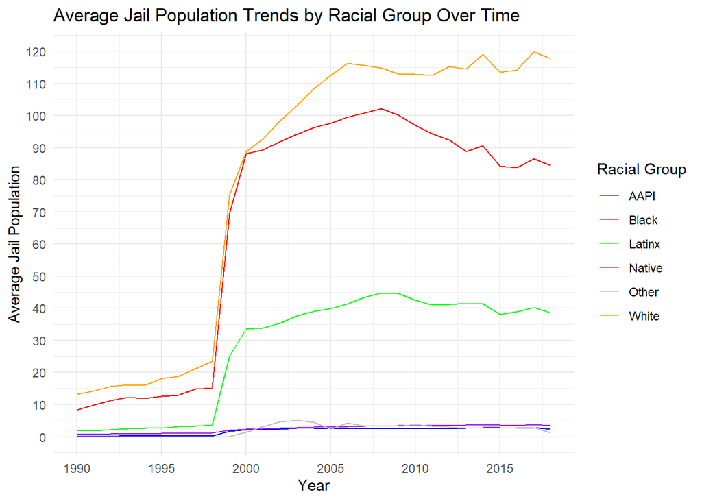

### Variable Comparison Chart

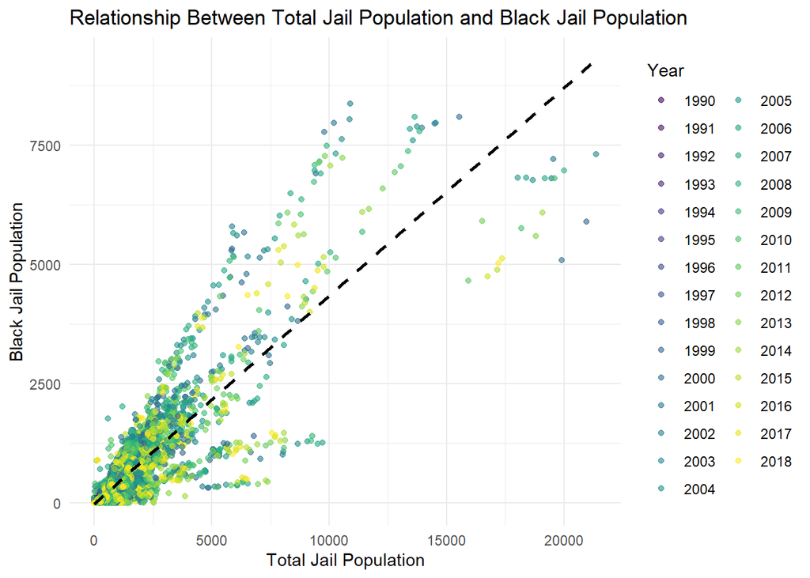

### Map

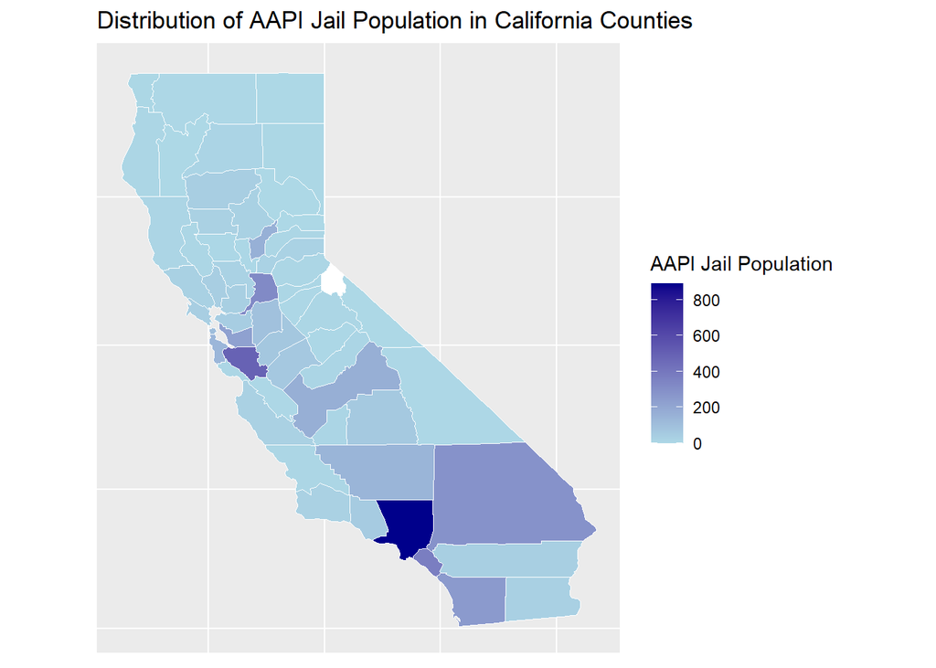